# Reduccion 15

9 actividades; límite 3 operarios, reducir dos semanas (Ackoff sin recursos falla)

# Enunciado

Considere el proyecto cuyo cuadro de prelaciones, duración normal y tope (semanas), operarios por actividad y coste unitario de reducción (k€/semana) se adjunta. Cada actividad necesita un número fijo de operarios durante toda su duración y la empresa dispone como máximo de 3 operarios en cada semana. Las actividades con CUR infinito no pueden acelerarse. Se quiere reducir la duración del proyecto **dos semanas** respetando el límite de operarios.

1. Determine la duración del proyecto sin límite de recursos y con el límite de operarios (algoritmo de asignación). Indique la cadena crítica con recursos: qué actividades fijan la duración y qué esperas por recurso intervienen.

2. Aplique el algoritmo de Ackoff-Sasieni ignorando los recursos para reducir dos semanas, aplique esas reducciones y replanifique con el límite de operarios. ¿Se ha conseguido reducir la duración del proyecto con recursos? ¿Por qué?

3. Reduzca ahora dos semanas teniendo en cuenta el límite: pruebe en cada paso los candidatos (cortes de la cadena crítica con recursos, actividades sueltas y parejas) y elija el más barato que de verdad acorte el proyecto replanificado. Compare el sobrecoste con el del apartado anterior.

4. Suponga que acelerar una actividad exige un operario más por cada semana recortada (modelo con recurso). ¿Cambia la solución?

5. Alternativa: contratar un operario más (límite 4) sin acelerar nada. ¿Qué duración se obtiene? ¿Compensa frente a acelerar?

Tabla 1: Cuadro de datos del enunciado

| activity | predecessor | duration | operarios | cap_duration | ucr |
| --- | --- | --- | --- | --- | --- |
| A | --- | 2 | 2 | 1 | 3.0 |
| B | --- | 7 | 1 | 4 | 3.0 |
| C | A | 4 | 2 | 4 | inf |
| D | C | 6 | 1 | 4 | 6.0 |
| E | C | 4 | 1 | 2 | 2.0 |
| F | B,E | 1 | 2 | 1 | inf |
| G | F | 2 | 3 | 1 | 7.0 |
| H | D,F | 1 | 1 | 1 | inf |
| I | G | 7 | 1 | 5 | 6.0 |

El proyecto corresponde a la rehabilitación de una nave industrial para un taller; las actividades son las siguientes (las duraciones del cuadro están en semanas).

Tabla 2: Descripción de las actividades

|  | Descripción |
| --- | --- |
| A | Levantamiento topográfico y mediciones |
| B | Proyecto de ejecución y licencia |
| C | Desmontaje de instalaciones antiguas |
| D | Demolición de tabiquería interior |
| E | Refuerzo de la estructura metálica |
| F | Reparación de la cubierta |
| G | Solera y canalizaciones |
| H | Cerramientos y carpintería exterior |
| I | Instalación eléctrica |

# Resolución

## Apartado 1

1. Determine la duración del proyecto sin límite de recursos y con el límite de operarios (algoritmo de asignación). Indique la cadena crítica con recursos: qué actividades fijan la duración y qué esperas por recurso intervienen.

Cálculo de los tiempos tempranos y tardíos de los sucesos y de las holguras totales paso a paso. El primer paso muestra el grafo resuelto; a partir del siguiente se calcula desde el principio (avance con los botones):

paso 0 de 28

[figure not shown]

Figura 1: Grafo PERT con las duraciones normales y el camino crítico (sin límite de operarios)

Tabla 3: Calendario sin límite de recursos

[figure not shown]

Haz clic en un número de la tabla para ver cómo se calcula.

👆 **Interactivo:** haz clic en cualquier celda de la tabla para ver cómo se calcula (otro clic la deselecciona).

| Actividad | Duración | Inicio más temprano | Fin más temprano | Inicio más tardío | Fin más tardío | H total | H libre | H independiente |
| --- | --- | --- | --- | --- | --- | --- | --- | --- |
| A | 2 | 0 | 2 | 0 | 2 | 0 | 0 | 0 |
| B | 7 | 0 | 7 | 3 | 10 | 3 | 3 | 3 |
| C | 4 | 2 | 6 | 2 | 6 | 0 | 0 | 0 |
| D | 6 | 6 | 12 | 13 | 19 | 7 | 0 | 0 |
| E | 4 | 6 | 10 | 6 | 10 | 0 | 0 | 0 |
| F | 1 | 10 | 11 | 10 | 11 | 0 | 0 | 0 |
| G | 2 | 11 | 13 | 11 | 13 | 0 | 0 | 0 |
| H | 1 | 12 | 13 | 19 | 20 | 7 | 7 | 0 |
| I | 7 | 13 | 20 | 13 | 20 | 0 | 0 | 0 |

[figure not shown]

Figura 2: Gantt de inicios más tempranos con los operarios de cada actividad (fila Total: carga semanal)

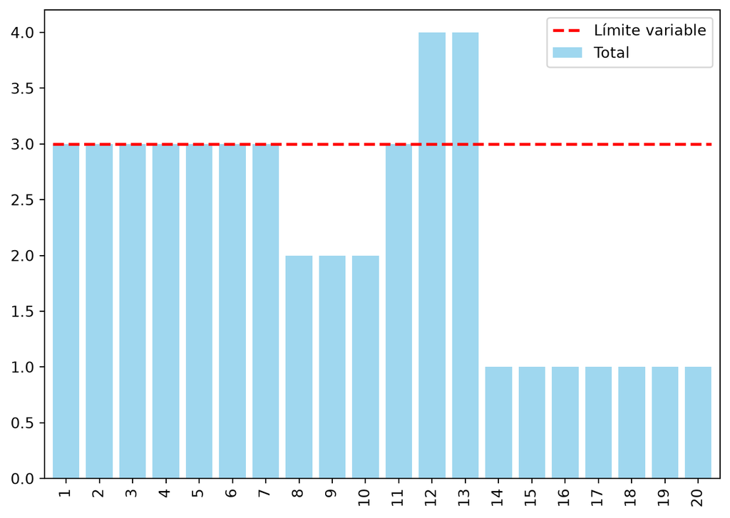

Figura 3: Carga de operarios frente al límite

Sin límite el proyecto dura 20 semanas, pero en las semanas 12, 13 harían falta 4, 4 operarios, más de los 3 disponibles: hay que reprogramar.

El algoritmo de asignación recorre las semanas una a una. En cada semana son *candidatas* las actividades no empezadas cuyas predecesoras han terminado; se ordenan por prioridad (menor inicio más tardío en el calendario sin recursos, después menor duración) y cada una empieza si, en todas las semanas que ocuparía, los operarios ya comprometidos más los suyos no superan el límite; si no, espera. La traza muestra la decisión de cada semana y, entre paréntesis, el recurso que bloquea a las que esperan.

Periodo 1. Empiezan: [‘A’, ‘B’]. Esperan: []

Periodo 3. Empiezan: [‘C’]. Esperan: []

Periodo 7. Empiezan: [‘E’, ‘D’]. Esperan: []

Periodo 11. Empiezan: [‘F’]. Esperan: []

Periodo 12. Empiezan: []. Esperan: [‘G (operarios)’]

Periodo 13. Empiezan: [‘G’]. Esperan: [‘H (operarios)’]

Periodo 14. Empiezan: []. Esperan: [‘H (operarios)’]

Periodo 15. Empiezan: [‘I’, ‘H’]. Esperan: []

[figure not shown]

Figura 4: Gantt con el límite de operarios (filas 💤: esperas por falta de operarios)

Tabla 4: Calendario con recursos: inicio, fin y espera de cada actividad

|  | inicio sin límite | inicio con límite | fin con límite | espera (semanas) |
| --- | --- | --- | --- | --- |
| A | 0 | 0 | 2 | 0 |
| B | 0 | 0 | 7 | 0 |
| C | 2 | 2 | 6 | 0 |
| D | 6 | 6 | 12 | 0 |
| E | 6 | 6 | 10 | 0 |
| F | 10 | 10 | 11 | 0 |
| G | 11 | 12 | 14 | 1 |
| H | 12 | 14 | 15 | 2 |
| I | 13 | 14 | 21 | 0 |

Tabla 5: Carga de operarios semana a semana frente al límite

| periodo | 1 | 2 | 3 | 4 | 5 | 6 | 7 | 8 | 9 | 10 | 11 | 12 | 13 | 14 | 15 | 16 | 17 | 18 | 19 | 20 | 21 |
| --- | --- | --- | --- | --- | --- | --- | --- | --- | --- | --- | --- | --- | --- | --- | --- | --- | --- | --- | --- | --- | --- |
| operarios ocupados | 3.0 | 3.0 | 3.0 | 3.0 | 3.0 | 3.0 | 3.0 | 2.0 | 2.0 | 2.0 | 3.0 | 1.0 | 3.0 | 3.0 | 2.0 | 1.0 | 1.0 | 1.0 | 1.0 | 1.0 | 1.0 |
| límite | 3.0 | 3.0 | 3.0 | 3.0 | 3.0 | 3.0 | 3.0 | 3.0 | 3.0 | 3.0 | 3.0 | 3.0 | 3.0 | 3.0 | 3.0 | 3.0 | 3.0 | 3.0 | 3.0 | 3.0 | 3.0 |

Sin límite: 20 semanas. Con 3 operarios: 21 semanas (1 más). Cadena crítica con recursos: A, C, D, G, I.

Tabla 6: Arcos de la cadena crítica con recursos

|  | de | a | motivo (precedencia o recurso) |
| --- | --- | --- | --- |
| 0 | A | C | precedencia |
| 1 | C | D | precedencia |
| 2 | D | G | recurso |
| 3 | G | I | precedencia |

La cadena crítica con recursos se lee hacia atrás desde la última actividad: cada arco une una actividad con otra que empieza justo cuando ella termina, bien porque es su predecesora (*precedencia*), bien porque le libera los operarios que esperaba (*recurso*). Los arcos de recurso son esperas, no prelaciones: la duración la fija esa cadena (precedencias más esperas), no el camino crítico del grafo.

## Apartado 2

2. Aplique el algoritmo de Ackoff-Sasieni ignorando los recursos para reducir dos semanas, aplique esas reducciones y replanifique con el límite de operarios. ¿Se ha conseguido reducir la duración del proyecto con recursos? ¿Por qué?

Ackoff-Sasieni sólo mira el grafo: acorta en cada paso, una semana, la combinación más barata de actividades que reduce todas las rutas críticas *sin recursos*. La tabla muestra, para cada ruta, el CUR de sus actividades y su duración tras cada paso.

Tabla 7: Algoritmo de Ackoff-Sasieni sin tener en cuenta los recursos

paso -1 de 2

[figure not shown]

Algoritmo de Ackoff-Sasieni: tabla completa. Pulse «siguiente» para ver cómo se construye.

Tabla 8: Opciones consideradas en cada paso

| paso | duración | rutas críticas | opciones (coste) | elegida | coste del paso |
| --- | --- | --- | --- | --- | --- |
| 1 | 20 | Route_2 | E (2); A (3); I (6); G (7) | E | 2.0 |
| 2 | 19 | Route_2 | E (2); A (3); I (6); G (7) | E | 2.0 |

| paso | actividades acortadas | coste del paso |
| --- | --- | --- |
| 1 | E | 2.0 |
| 2 | E | 2.0 |

Aplicadas esas reducciones, se vuelve a programar con el límite de operarios:

Periodo 1. Empiezan: [‘A’, ‘B’]. Esperan: []

Periodo 3. Empiezan: [‘C’]. Esperan: []

Periodo 7. Empiezan: [‘E’, ‘D’]. Esperan: []

Periodo 9. Empiezan: [‘F’]. Esperan: []

Periodo 10. Empiezan: []. Esperan: [‘G (operarios)’]

Periodo 11. Empiezan: []. Esperan: [‘G (operarios)’]

Periodo 12. Empiezan: []. Esperan: [‘G (operarios)’]

Periodo 13. Empiezan: [‘G’]. Esperan: [‘H (operarios)’]

Periodo 14. Empiezan: []. Esperan: [‘H (operarios)’]

Periodo 15. Empiezan: [‘I’, ‘H’]. Esperan: []

[figure not shown]

Figura 5: Gantt con el límite de operarios tras las reducciones de Ackoff-Sasieni

Tabla 9: Duración e inicio de cada actividad antes y después de aplicar Ackoff-Sasieni (con el límite)

|  | A | B | C | D | E | F | G | H | I |
| --- | --- | --- | --- | --- | --- | --- | --- | --- | --- |
| duración normal | 2 | 7 | 4 | 6 | 4 | 1 | 2 | 1 | 7 |
| duración Ackoff | 2 | 7 | 4 | 6 | 2 | 1 | 2 | 1 | 7 |
| inicio con límite (antes) | 0 | 0 | 2 | 6 | 6 | 10 | 12 | 14 | 14 |
| inicio con límite (después) | 0 | 0 | 2 | 6 | 6 | 8 | 12 | 14 | 14 |
| fin con límite (antes) | 2 | 7 | 6 | 12 | 10 | 11 | 14 | 15 | 21 |
| fin con límite (después) | 2 | 7 | 6 | 12 | 8 | 9 | 14 | 15 | 21 |

Ackoff sin recursos reduce el proyecto a 18 semanas sobre el papel (coste 4 k€), pero con el límite de operarios la duración es 21 semanas (antes 21). Las actividades acortadas (E) están en el camino crítico del grafo, pero lo que manda con recursos es la cadena A, C, D, G, I: el dinero se gasta sin acortar lo que de verdad fija el plazo.

## Apartado 3

3. Reduzca ahora dos semanas teniendo en cuenta el límite: pruebe en cada paso los candidatos (cortes de la cadena crítica con recursos, actividades sueltas y parejas) y elija el más barato que de verdad acorte el proyecto replanificado. Compare el sobrecoste con el del apartado anterior.

`crashing_recursos` repite en cada paso cuatro operaciones: (1) programa con el límite, (2) halla la cadena crítica con recursos, (3) evalúa como candidatos las actividades reducibles de esa cadena una a una, por parejas y el corte de coste mínimo de la cadena, **replanificando** con cada candidato, y (4) se queda con el más barato que de verdad acorta la duración replanificada. La tabla muestra, paso a paso, la cadena crítica, lo que habría elegido Ackoff-Sasieni sin recursos, cuántos candidatos se evaluaron y cuántas reducciones de una sola actividad no acortaron nada.

Tabla 10: Crashing con recursos limitados, paso a paso

| paso | cadena_critica | ackoff_sin_recursos | candidatos_evaluados | reducciones_sin_efecto | actividades | coste_paso | coste_acumulado | duracion_antes | duracion_despues |
| --- | --- | --- | --- | --- | --- | --- | --- | --- | --- |
| 1 | A, C, D, G, I | E | 10 | 0 | A | 3.0 | 3.0 | 21 | 20 |
| 2 | A, C, D, G, I | E | 6 | 0 | D | 6.0 | 9.0 | 20 | 19 |

Tabla 11: Duraciones finales y semanas recortadas a cada actividad

| activity | A | B | C | D | E | F | G | H | I |
| --- | --- | --- | --- | --- | --- | --- | --- | --- | --- |
| duración normal | 2.0 | 7.0 | 4.0 | 6.0 | 4.0 | 1.0 | 2.0 | 1.0 | 7.0 |
| duración tope | 1.0 | 4.0 | 4.0 | 4.0 | 2.0 | 1.0 | 1.0 | 1.0 | 5.0 |
| duración final | 1.0 | 7.0 | 4.0 | 5.0 | 4.0 | 1.0 | 2.0 | 1.0 | 7.0 |
| recortado | 1.0 | 0.0 | 0.0 | 1.0 | 0.0 | 0.0 | 0.0 | 0.0 | 0.0 |
| CUR | 3.0 | 3.0 | inf | 6.0 | 2.0 | inf | 7.0 | inf | 6.0 |

[figure not shown]

Figura 6: Gantt con el límite de operarios tras el crashing con recursos

Duración 21 → 19 semanas (parada: «reducción alcanzada») con un sobrecoste de 9 k€, frente a 4 k€ de Ackoff sin recursos, que no consiguió reducir la duración con recursos (quedó en 21). La diferencia está en qué actividades se acortan: las de la cadena crítica con recursos, comprobando en cada paso que la replanificación realmente termina antes.

## Apartado 4

4. Suponga que acelerar una actividad exige un operario más por cada semana recortada (modelo con recurso). ¿Cambia la solución?

En el modelo *con recurso*, acelerar una actividad consume operarios: cada semana recortada añade un operario a su demanda, de modo que la reducción puede chocar con el mismo límite que intenta esquivar.

Tabla 12: Crashing con recursos cuando acelerar consume un operario por semana recortada

| paso | cadena_critica | candidatos_evaluados | actividades | coste_paso | coste_acumulado | duracion_antes | duracion_despues |
| --- | --- | --- | --- | --- | --- | --- | --- |
| 1 | A, C, D, G, I | 6 | A | 3.0 | 3.0 | 21 | 20 |
| 2 | A, C, D, G, I | 3 | I | 6.0 | 9.0 | 20 | 19 |

Tabla 13: Demanda de operarios de cada actividad tras las reducciones (modelo con recurso)

| activity | A | B | C | D | E | F | G | H | I |
| --- | --- | --- | --- | --- | --- | --- | --- | --- | --- |
| operarios (normal) | 2.0 | 1.0 | 2.0 | 1.0 | 1.0 | 2.0 | 3.0 | 1.0 | 1.0 |
| operarios (tras recortar) | 3.0 | 1.0 | 2.0 | 1.0 | 1.0 | 2.0 | 3.0 | 1.0 | 2.0 |
| recortado | 1.0 | 0.0 | 0.0 | 0.0 | 0.0 | 0.0 | 0.0 | 0.0 | 1.0 |

Modelo con recurso: parada «reducción alcanzada», duración final 19 semanas, sobrecoste 9 k€ (modelo con dinero: 19 semanas y 9 k€). Aun consumiendo el recurso, el límite todavía permite la reducción pedida, pero con otras actividades o con un coste distinto.

## Apartado 5

5. Alternativa: contratar un operario más (límite 4) sin acelerar nada. ¿Qué duración se obtiene? ¿Compensa frente a acelerar?

Periodo 1. Empiezan: [‘A’, ‘B’]. Esperan: []

Periodo 3. Empiezan: [‘C’]. Esperan: []

Periodo 7. Empiezan: [‘E’, ‘D’]. Esperan: []

Periodo 11. Empiezan: [‘F’]. Esperan: []

Periodo 12. Empiezan: [‘G’]. Esperan: []

Periodo 13. Empiezan: [‘H’]. Esperan: []

Periodo 14. Empiezan: [‘I’]. Esperan: []

[figure not shown]

Figura 7: Gantt con un operario más, sin acelerar ninguna actividad

Con 4 operarios, sin acelerar nada: 20 semanas (antes 21). Se ahorran 1 semana(s). Reducir 2 semanas acelerando cuesta 9 k€. Compensa contratar si el coste del operario adicional durante las 20 semanas del proyecto es menor que ese sobrecoste (y la comparación es justa solo con el mismo número de semanas ahorradas).